# OLS estimator: Unbaised and consistent estimator

# Properties of the OLS estimator

## What will we learn in this empirical exercise ?

1. Show the unbiasedness of the OLS estimator.
2. Show the consistency of the OLS estimator.

## Theory behind practice

Let us consider a linear regression with one explanatory variable, i.e. $y_t = \beta_1 + \beta_2 x_t + \epsilon_t$. We assume that the following assumptions hold:

1. No Collinearity: $x=(x_1,...,x_T)'$ is not constant over time.
2. Strict exogeneity: $E(\epsilon_t|x) = 0 ~~\forall t\in[1,T]$.

When these conditions hold, the OLS estimator is unbiased and consistent. The OLS estimator is also efficient, i.e. minimum variance among the linear unbiased estimators, when we add the following assumptions:

3. White noise: $E(\epsilon_t\epsilon_{j}|x)=0 ~~\forall t\neq j$.
4. Homoskedasticity: $E(\epsilon_t^2|x)=\sigma^2 ~~\forall t\in[1,T]$.

In this exercise, we show the unbiasedness and the consistency of the OLS estimator. Note that the strict exogeneity implies that $E(\epsilon_t)=E(E(\epsilon_t|x)) = 0$ by the law of iterated expectations.

## From theory to practice

To show the OLS properties, we need to be in a controlled environment. Therefore, we will simulate the explanatory variable and the dependent variable to ensure that the OLS assumptions are valid. We create a function that generates thousands of dependent variables using the linear regression $y_t = \beta_1 + \beta_2 x_t + \epsilon_t$, and estimates the OLS estimates for each generated dependent variable. This function requires the explanatory variable, the true coefficients, the variance of the error term and the number of generated series as inputs. Unbiasedness means that, on average, we should obtain the true coefficients.

```python
import sys
import matplotlib.pyplot as plt
import pandas as pd
import numpy as np
import seaborn as sns


def summary(y):
    y = np.array(y,ndmin=2)
    K = np.size(y,0)
    quant = np.linspace(25,100,4)/100
    Stats = np.zeros([K,6])
    for i in range(0,K):
        Stats[i,0] = np.min(y[i,:])
        quantile = np.quantile(y,quant)
        Stats[i,[1,2,4,5]] = quantile
        Stats[i,3] = np.mean(y[i,:])

    df=pd.DataFrame(Stats,columns=["Min.","1st. Qu.","Median","Mean","3rd Quar.","Max."])
    return(df)

def OLS_bias(x,beta_true,sigma_sq=1,nb_sim = 10000,dist=1):
    K = np.size(beta_true)
    if(K!=2):sys.exit('Your size parameter should be two')

    T = np.size(x)
    x_bar = np.mean(x)
    beta_ols = np.zeros([nb_sim,K])
    for i in range(0,nb_sim):
        if(dist==1):
            y = beta_true[0] + beta_true[1]*x + np.random.normal(0,np.sqrt(sigma_sq),T)
        else:
            y = beta_true[0] + beta_true[1]*x + np.sqrt(sigma_sq)*np.random.standard_t(10,size=T)


        y_bar = np.mean(y)
        beta2 = np.dot(x-x_bar,y-y_bar)/np.dot(x-x_bar,x-x_bar)
        beta1 = y_bar - beta2*x_bar
        beta_ols[i,:] = (beta1,beta2)

    beta_dev = beta_ols
    for i in range(0,K):
        sns.distplot(beta_ols[:,i], hist=True, kde=True, bins=80, color = 'darkblue', hist_kws={'edgecolor':'black'},kde_kws={'linewidth': 4})
        plt.title("Histogram and density of beta" + str(i+1))
        plt.show()
        beta_dev[:,i] = beta_ols[:,i]-beta_true[i]

    df1 = summary(np.transpose(beta_dev))
    df = pd.DataFrame(np.transpose(np.array(df1,ndmin=2)),columns=["Bias of beta 1","Bias of beta 2"],index=df1.columns)


    return(df)
```

The *OLS_bias* function generates *nb_sim* dependent variables of size Tx1 using draws from a Normal distribution if *dist=1* or from a student distribution if *dist!=1*. For each dependent variable, the OLS estimates are computed and compared to the true coefficients.

```python
T = 100
x = np.random.normal(0,1,T)
beta = OLS_bias(x,np.asarray((1,2)),sigma_sq=3,nb_sim = 10000,dist=1)
```

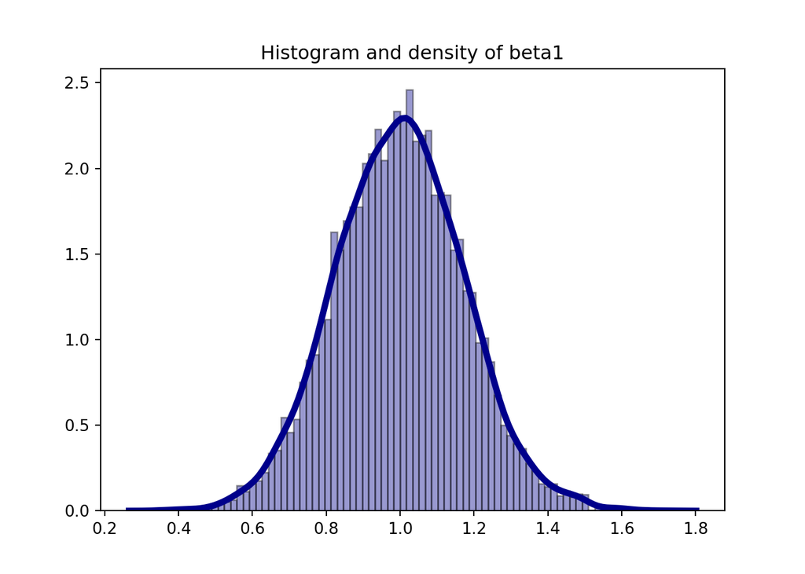

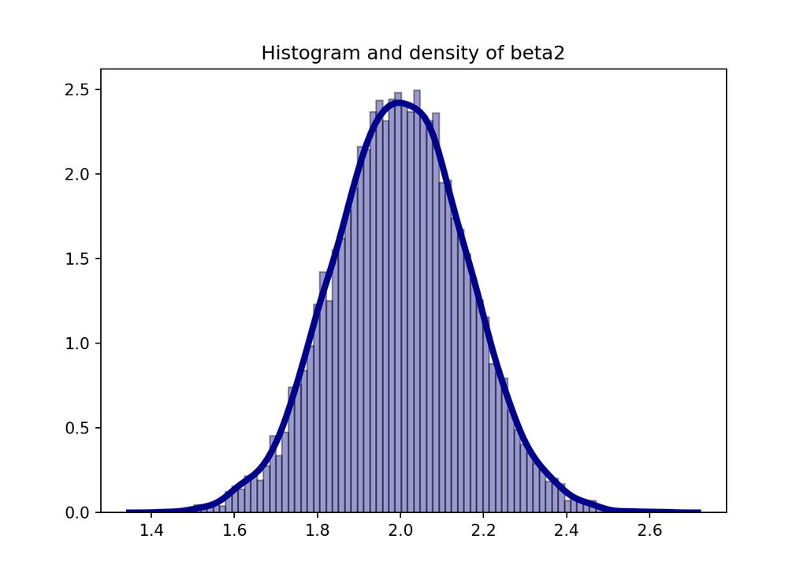

```python
print(beta)
```

```
##            Bias of beta 1  Bias of beta 2
## Min.            -0.646610       -0.572478
## 1st. Qu.        -0.113588       -0.113588
## Median          -0.000233       -0.000233
## Mean            -0.000938        0.000062
## 3rd Quar.        0.111169        0.111169
## Max.             0.713781        0.713781
```

We observe that the OLS estimates are centered around the true values. Also, the biases for the two estimates are small. We can also check that the Normal distribution assumption is not required for unbiasedness.

```python
beta = OLS_bias(x,np.asarray((1,2)),sigma_sq=3,nb_sim = 10000,dist=0)
```

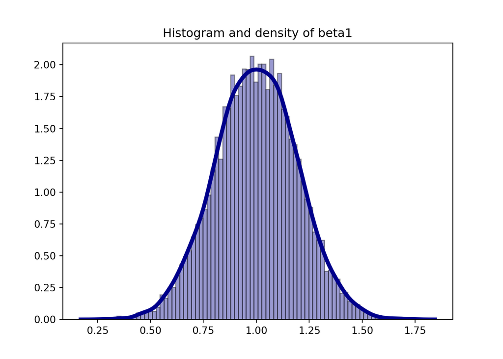

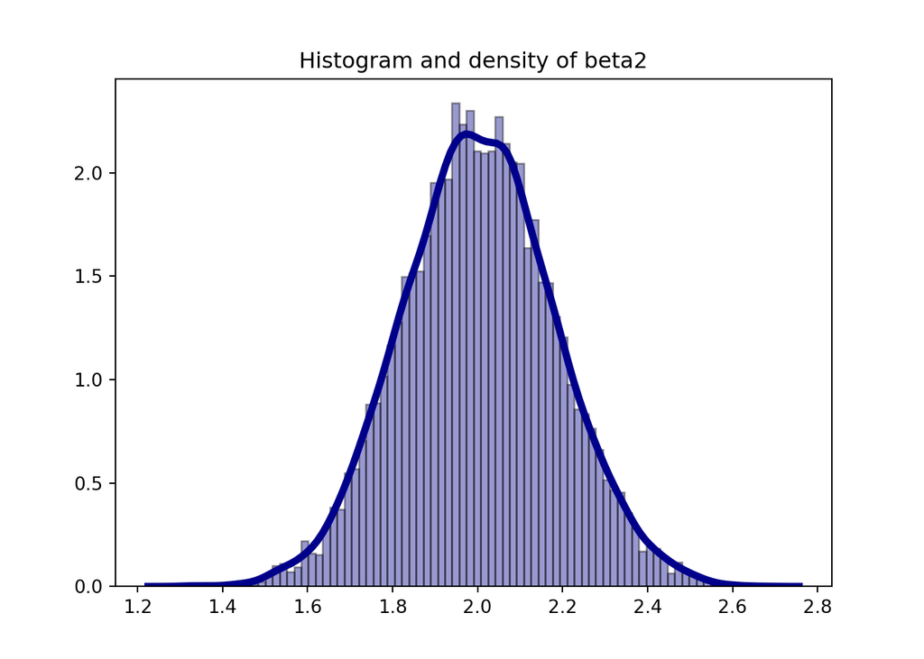

```python
print(beta)
```

```
##            Bias of beta 1  Bias of beta 2
## Min.            -0.732267       -0.685631
## 1st. Qu.        -0.124457       -0.124457
## Median           0.000871        0.000871
## Mean            -0.000711        0.003821
## 3rd Quar.        0.126654        0.126654
## Max.             0.745951        0.745951
```

Using a student distribution to simulate the error terms, we also end up with tiny biases. Note that the shape of the OLS estimates is close to a Normal distribution even though the error terms are driven by a student distribution. This is a consequence of the central limit theorem as we will see in class. Now, we create a function to show that the OLS estimates are biased when the correlation between the error terms and the explanatory variables are different from zero.

```python
def OLS_bias_exo(x,beta_true,correl=0.5,sigma_sq=1,nb_sim = 10000,dist=1):
    K = np.size(beta_true)
    if(K!=2):sys.exit('Your size parameter should be two')

    T = np.size(x)
    x_bar = np.mean(x)
    beta_ols = np.zeros([nb_sim,K])
    for i in range(0,nb_sim):
        if(dist==1):
            y = beta_true[0] + beta_true[1]*x + np.sqrt(sigma_sq)*(np.random.normal(0,1,T)+correl*x)
        else:
            y = beta_true[0] + beta_true[1]*x + np.sqrt(sigma_sq)*(np.random.standard_t(10,size=T)+correl*x)


        y_bar = np.mean(y)
        beta2 = np.dot(x-x_bar,y-y_bar)/np.dot(x-x_bar,x-x_bar)
        beta1 = y_bar - beta2*x_bar
        beta_ols[i,:] = (beta1,beta2)

    beta_dev = beta_ols
    for k in range(0,K):
        sns.distplot(beta_ols[:,k], hist=True, kde=True, bins=80, color = 'darkblue', hist_kws={'edgecolor':'black'},kde_kws={'linewidth': 4})
        plt.title("Histogram and density of beta" + str(k+1))
        plt.show()
        beta_dev[:,k] = beta_ols[:,k]-beta_true[k]

    df1 = summary(np.transpose(beta_dev))
    df = pd.DataFrame(np.transpose(np.array(df1,ndmin=2)),columns=["Bias of beta 1","Bias of beta 2"],index=df1.columns)


    return(df)
```

The *OLS_bias_exo* function adds a correlation input *correl*. When *correl* equals zero, the strict exogeneity assumption holds. From the function, we understand easily that the OLS estimates will be biased since the true linear regression (with respect to *x*) is now $y_t = \beta_1 + x_t(\beta_2+\sigma \text{correl}) + \epsilon_t$. Let us check this result out by running the function.

```python
correlation = 0.8
sigma_sq = 2
beta = OLS_bias_exo(x,np.asarray((1,2)),correl=correlation,sigma_sq=sigma_sq,nb_sim = 10000,dist=1)
```

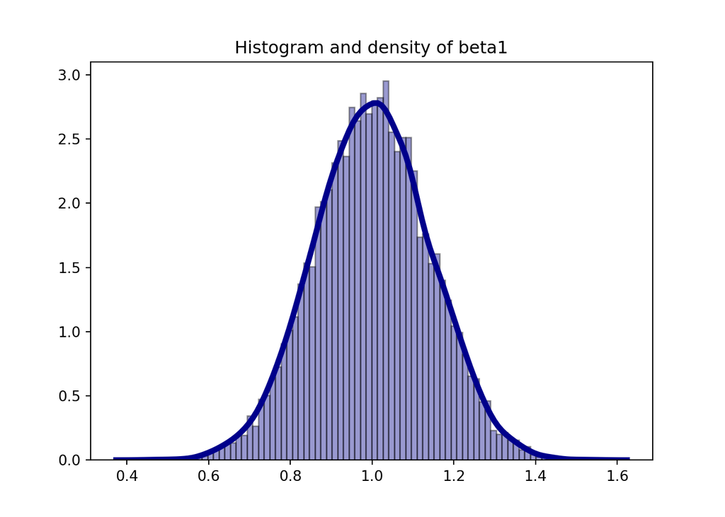

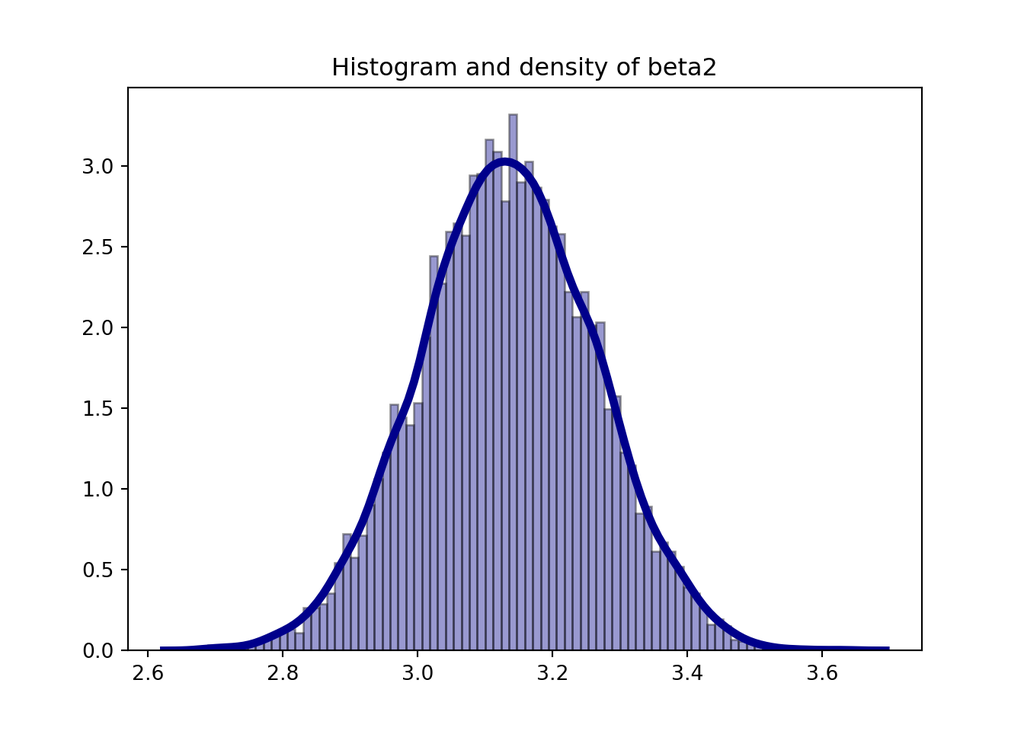

```python
print("Expected bias for beta2: " + str(np.sqrt(sigma_sq)*correlation))
```

```
## Expected bias for beta2: 1.1313708498984762
```

```python
print(beta)
```

```
##            Bias of beta 1  Bias of beta 2
## Min.            -0.555441        0.689146
## 1st. Qu.         0.000717        0.000717
## Median           0.621029        0.621029
## Mean             0.000718        1.133713
## 3rd Quar.        1.134092        1.134092
## Max.             1.629139        1.629139
```

As expected, the bias of $\beta_2$ is close to $\sigma \text{correl}$.

## OLS Consistency

We now turn to the consistency property. Again, only the no-collinearity and the strict exogeneity are required to have the consistency property. We first write a function to show that when the sample size increases, the OLS estimates shrinks toward constants (which are the true coefficients when the assumptions are not violated).

```python
def OLS_consistency(beta_true=np.asarray((1,2)),sigma_sq = 2,correl=0,nb_sim = 1000):
    K = np.size(beta_true)
    if(K!=2):sys.exit('Your size parameter should be two')
    T = 1000
    nb_iter = 50
    inter = np.ceil(np.linspace(10,T,nb_iter)).astype(int)
    x = np.random.uniform(0,1,T)*30

    quant = np.arange(0.05, 1, 0.05)
    nb_quant = np.size(quant)

    beta_ols = np.zeros((nb_sim,K,nb_iter))
    beta_quant = np.zeros((nb_quant,nb_iter,K))
    for i in range(0,nb_iter):
        T_cur = inter[i]
        x_cur = x[0:T_cur]
        for j in range(0,nb_sim):
            y_cur = beta_true[0] + beta_true[1]*x_cur + np.sqrt(sigma_sq)*(np.random.normal(0,1,T_cur)+correl*x_cur)
            x_bar = np.mean(x_cur)
            y_bar = np.mean(y_cur)
            beta2 = np.dot(x_cur-x_bar,y_cur-y_bar)/np.dot(x_cur-x_bar,x_cur-x_bar)
            beta1 = y_bar - beta2*x_bar
            beta_ols[j,:,i] = (beta1,beta2)

        for k in range(0,K):
            beta_quant[:,i,k] = np.quantile(beta_ols[:,k,i],quant)

    for k in range(0,K):
        fig, ax = plt.subplots(figsize=(10, 10))
        plt.plot(inter,beta_quant[10,:,k],'-b',linewidth=3)
        plt.plot(inter,beta_quant[1,:,k],'-.k',linewidth=1.5)
        plt.plot(inter,beta_quant[nb_quant-1,:,k],'-.k',linewidth=1.5)
        ax.set(xlabel="T", ylabel="Beta"+ str(k),title="Consistency")
        plt.show()

    return(beta_quant)
```

Again, we can play with the *correl* parameter to show the consistency property. When *correl=0*, the OLS estimator is consistent. It is not when *correl* is different from zero.

```python
beta_test = OLS_consistency(np.asarray((1,2)),nb_sim = 1000)
```

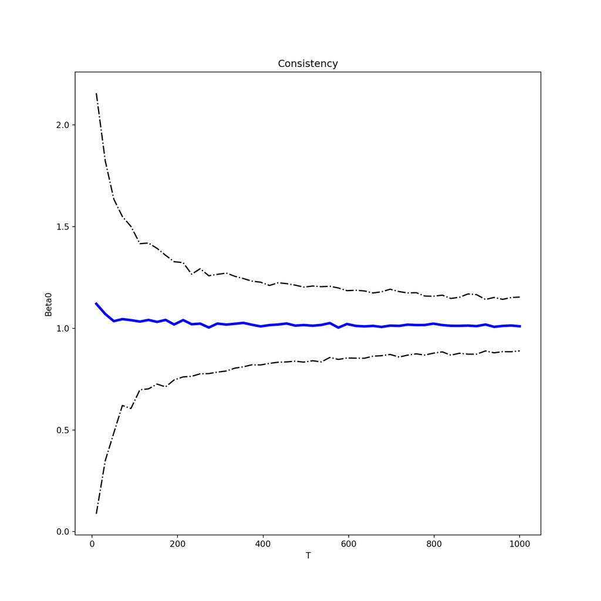

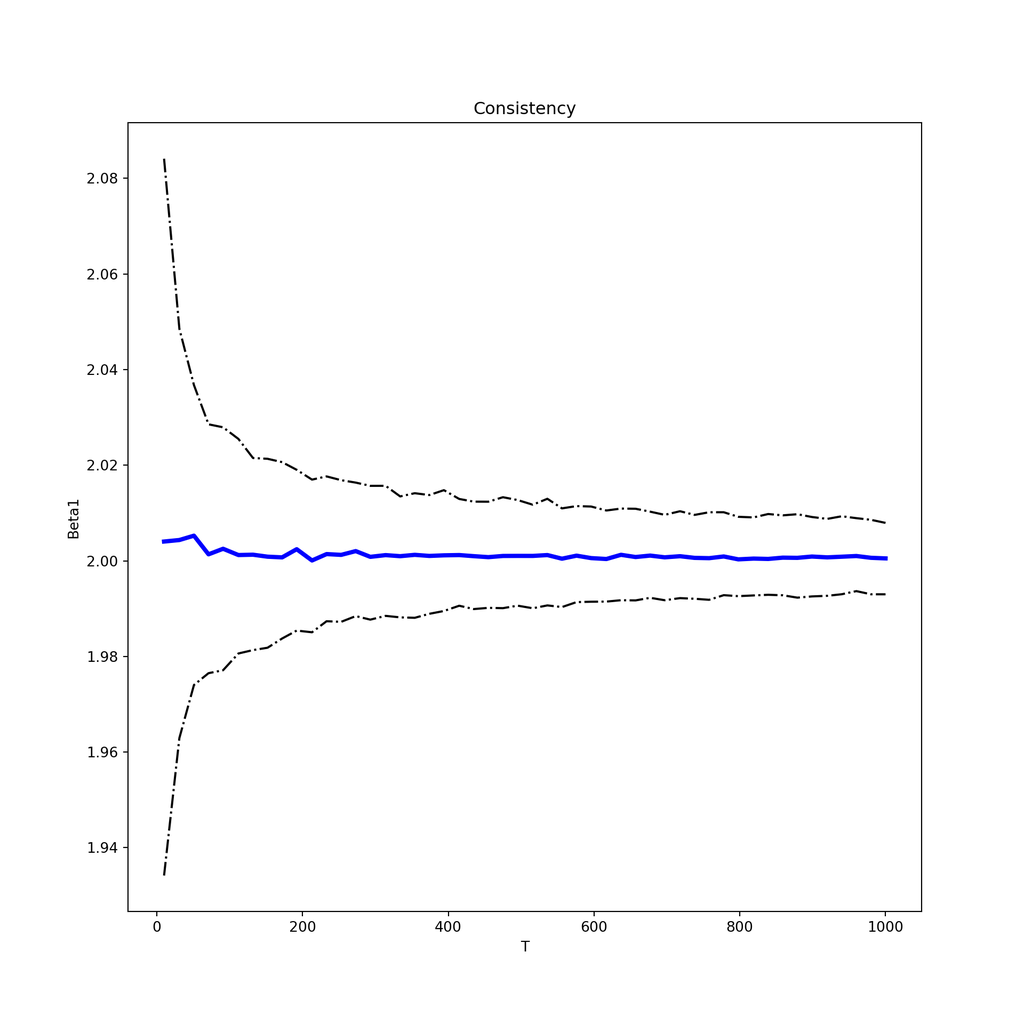

When the strict exogeneity does not hold, the OLS estimator also converges to a constant but this constant is not the true value anymore.

```python
beta_test = OLS_consistency(np.asarray((1,2)),correl = 0.9,nb_sim = 1000)
```

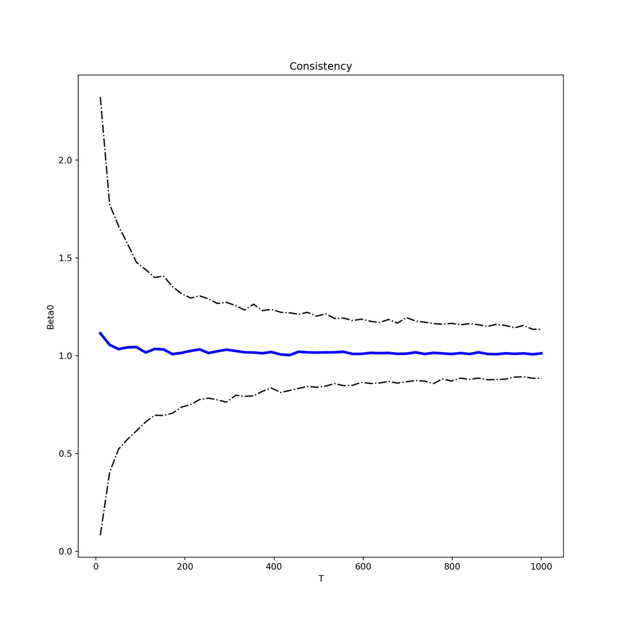

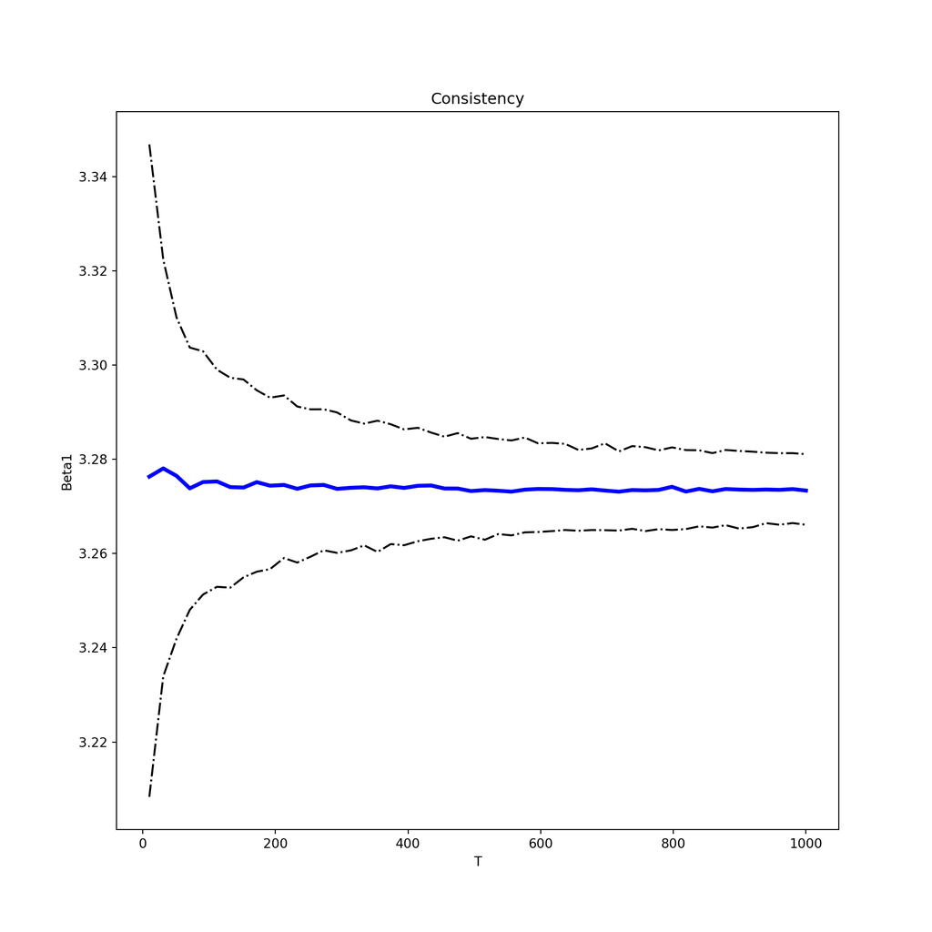